# Risk Factor Analysis

## Outcome Variable

**Outcome Variable:** stunted

## Predictor Variables

**Intervention Variable:** fhtcm

**Adjustment Set:**

unadjusted

## Stratifying Variables

The analysis was stratified on these variable(s):

- agecat
- studyid

The following strata were considered:

- agecat: 12 months, studyid: ki1000304b-SAS-FoodSuppl
- agecat: 12 months, studyid: ki1101329-Keneba
- agecat: 12 months, studyid: ki1135781-COHORTS
- agecat: 18 months, studyid: ki1000304b-SAS-FoodSuppl
- agecat: 18 months, studyid: ki1101329-Keneba
- agecat: 18 months, studyid: ki1135781-COHORTS
- agecat: 24 months, studyid: ki1101329-Keneba
- agecat: 24 months, studyid: ki1135781-COHORTS
- agecat: 3 months, studyid: ki1000304b-SAS-FoodSuppl
- agecat: 3 months, studyid: ki1101329-Keneba
- agecat: 3 months, studyid: ki1135781-COHORTS
- agecat: 6 months, studyid: ki1000304b-SAS-FoodSuppl
- agecat: 6 months, studyid: ki1101329-Keneba
- agecat: 6 months, studyid: ki1135781-COHORTS
- agecat: 9 months, studyid: ki1000304b-SAS-FoodSuppl
- agecat: 9 months, studyid: ki1101329-Keneba
- agecat: 9 months, studyid: ki1135781-COHORTS
- agecat: Birth, studyid: ki1101329-Keneba
- agecat: Birth, studyid: ki1135781-COHORTS

### Dropped Strata

Some strata were dropped due to rare outcomes:

- agecat: Birth, studyid: ki1135781-COHORTS
- agecat: 3 months, studyid: ki1000304b-SAS-FoodSuppl
- agecat: 3 months, studyid: ki1135781-COHORTS
- agecat: 6 months, studyid: ki1000304b-SAS-FoodSuppl
- agecat: 6 months, studyid: ki1135781-COHORTS
- agecat: 9 months, studyid: ki1000304b-SAS-FoodSuppl
- agecat: 9 months, studyid: ki1135781-COHORTS
- agecat: 12 months, studyid: ki1000304b-SAS-FoodSuppl
- agecat: 12 months, studyid: ki1135781-COHORTS
- agecat: 18 months, studyid: ki1000304b-SAS-FoodSuppl
- agecat: 18 months, studyid: ki1135781-COHORTS
- agecat: 24 months, studyid: ki1135781-COHORTS

## Methods Detail

We’re interested in the causal parameters $E[Y_a]$ for all values of $a \in \mathcal{A}$. These parameters represent the mean outcome if, possibly contrary to fact, we intervened to set all units to have $A=a$. Under the randomization and positivity assumptions, these are identified by the statistical parameters $\psi_a=E_W[E_{Y|A,W}(Y|A=a,W)]$. In addition, we’re interested in the mean of $Y$, $E[Y]$ under no intervention (the observed mean). We will estimate these parameters by using SuperLearner to fit the relevant likelihood factors – $E_{Y|A,W}(Y|A=a,W)$ and $p(A=a|W)$, and then updating our likelihood fit using a joint TMLE.

For unadjusted analyses ($W=\{\}$), initial likelihoods were estimated using Lrnr_glm to estimate the simple $E(Y|A)$ and Lrnr_mean to estimate $p(A)$. For adjusted analyses, a small library containing Lrnr_glmnet, Lrnr_xgboost, and Lrnr_mean was used.

Having estimated these parameters, we will then use the delta method to estimate relative risks and attributable risks relative to a prespecified baseline level of $A$.

# Results Detail

## Results Plots

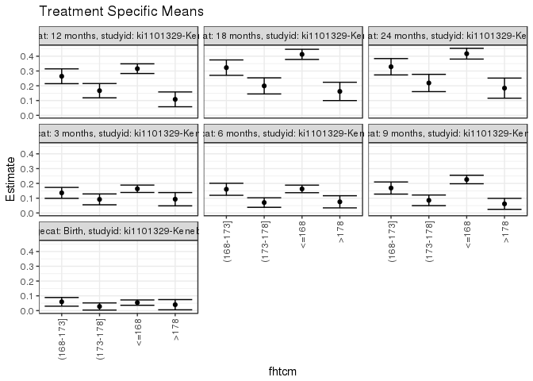

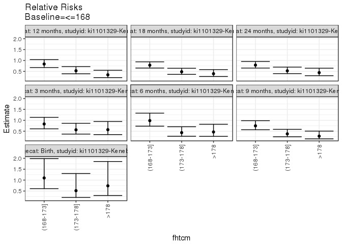

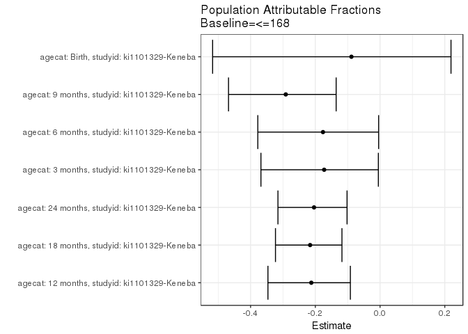

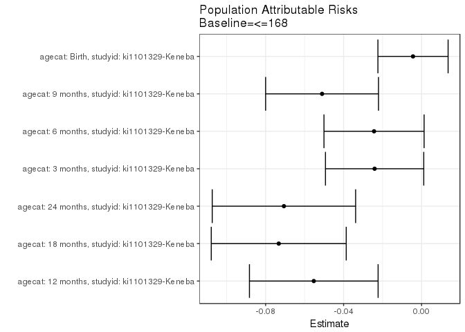

## Data Summary

| agecat | studyid | A | n | nA | nAY0 | nAY1 |
| --- | --- | --- | --- | --- | --- | --- |
| Birth | ki1000304b-SAS-FoodSuppl | <=168 | 0 | 0 | 0 | 0 |
| Birth | ki1000304b-SAS-FoodSuppl | (168-173] | 0 | 0 | 0 | 0 |
| Birth | ki1000304b-SAS-FoodSuppl | (173-178] | 0 | 0 | 0 | 0 |
| Birth | ki1000304b-SAS-FoodSuppl | >178 | 0 | 0 | 0 | 0 |
| Birth | ki1101329-Keneba | <=168 | 1165 | 609 | 576 | 33 |
| Birth | ki1101329-Keneba | (168-173] | 1165 | 252 | 237 | 15 |
| Birth | ki1101329-Keneba | (173-178] | 1165 | 179 | 174 | 5 |
| Birth | ki1101329-Keneba | >178 | 1165 | 125 | 120 | 5 |
| Birth | ki1135781-COHORTS | <=168 | 91 | 85 | 81 | 4 |
| Birth | ki1135781-COHORTS | (168-173] | 91 | 5 | 3 | 2 |
| Birth | ki1135781-COHORTS | (173-178] | 91 | 1 | 1 | 0 |
| Birth | ki1135781-COHORTS | >178 | 91 | 0 | 0 | 0 |
| 3 months | ki1000304b-SAS-FoodSuppl | <=168 | 92 | 79 | 50 | 29 |
| 3 months | ki1000304b-SAS-FoodSuppl | (168-173] | 92 | 8 | 3 | 5 |
| 3 months | ki1000304b-SAS-FoodSuppl | (173-178] | 92 | 4 | 3 | 1 |
| 3 months | ki1000304b-SAS-FoodSuppl | >178 | 92 | 1 | 1 | 0 |
| 3 months | ki1101329-Keneba | <=168 | 1562 | 831 | 695 | 136 |
| 3 months | ki1101329-Keneba | (168-173] | 1562 | 331 | 286 | 45 |
| 3 months | ki1101329-Keneba | (173-178] | 1562 | 239 | 217 | 22 |
| 3 months | ki1101329-Keneba | >178 | 1562 | 161 | 146 | 15 |
| 3 months | ki1135781-COHORTS | <=168 | 140 | 128 | 78 | 50 |
| 3 months | ki1135781-COHORTS | (168-173] | 140 | 6 | 2 | 4 |
| 3 months | ki1135781-COHORTS | (173-178] | 140 | 6 | 5 | 1 |
| 3 months | ki1135781-COHORTS | >178 | 140 | 0 | 0 | 0 |
| 6 months | ki1000304b-SAS-FoodSuppl | <=168 | 94 | 81 | 41 | 40 |
| 6 months | ki1000304b-SAS-FoodSuppl | (168-173] | 94 | 8 | 3 | 5 |
| 6 months | ki1000304b-SAS-FoodSuppl | (173-178] | 94 | 4 | 2 | 2 |
| 6 months | ki1000304b-SAS-FoodSuppl | >178 | 94 | 1 | 1 | 0 |
| 6 months | ki1101329-Keneba | <=168 | 1511 | 799 | 669 | 130 |
| 6 months | ki1101329-Keneba | (168-173] | 1511 | 312 | 262 | 50 |

[output cut: 54 more lines]

## Results Table

### Parameter: TSM

| agecat | studyid | intervention_level | baseline_level | estimate | ci_lower | ci_upper |
| --- | --- | --- | --- | --- | --- | --- |
| Birth | ki1101329-Keneba | <=168 | NA | 0.0541872 | 0.0361994 | 0.0721749 |
| Birth | ki1101329-Keneba | (168-173] | NA | 0.0595238 | 0.0302989 | 0.0887487 |
| Birth | ki1101329-Keneba | (173-178] | NA | 0.0279330 | 0.0037831 | 0.0520828 |
| Birth | ki1101329-Keneba | >178 | NA | 0.0400000 | 0.0056327 | 0.0743673 |
| 3 months | ki1101329-Keneba | <=168 | NA | 0.1636582 | 0.1384961 | 0.1888204 |
| 3 months | ki1101329-Keneba | (168-173] | NA | 0.1359517 | 0.0990170 | 0.1728863 |
| 3 months | ki1101329-Keneba | (173-178] | NA | 0.0920502 | 0.0553869 | 0.1287135 |
| 3 months | ki1101329-Keneba | >178 | NA | 0.0931677 | 0.0482549 | 0.1380805 |
| 6 months | ki1101329-Keneba | <=168 | NA | 0.1627034 | 0.1371024 | 0.1883043 |
| 6 months | ki1101329-Keneba | (168-173] | NA | 0.1602564 | 0.1195376 | 0.2009753 |
| 6 months | ki1101329-Keneba | (173-178] | NA | 0.0705394 | 0.0382013 | 0.1028775 |
| 6 months | ki1101329-Keneba | >178 | NA | 0.0754717 | 0.0343997 | 0.1165437 |
| 9 months | ki1101329-Keneba | <=168 | NA | 0.2263223 | 0.1975490 | 0.2550955 |
| 9 months | ki1101329-Keneba | (168-173] | NA | 0.1687500 | 0.1277010 | 0.2097990 |
| 9 months | ki1101329-Keneba | (173-178] | NA | 0.0854701 | 0.0496367 | 0.1213035 |
| 9 months | ki1101329-Keneba | >178 | NA | 0.0617284 | 0.0246570 | 0.0987998 |
| 12 months | ki1101329-Keneba | <=168 | NA | 0.3156533 | 0.2828776 | 0.3484290 |
| 12 months | ki1101329-Keneba | (168-173] | NA | 0.2642140 | 0.2142202 | 0.3142079 |
| 12 months | ki1101329-Keneba | (173-178] | NA | 0.1666667 | 0.1182757 | 0.2150576 |
| 12 months | ki1101329-Keneba | >178 | NA | 0.1081081 | 0.0580641 | 0.1581522 |
| 18 months | ki1101329-Keneba | <=168 | NA | 0.4123581 | 0.3780849 | 0.4466314 |
| 18 months | ki1101329-Keneba | (168-173] | NA | 0.3225806 | 0.2705253 | 0.3746360 |
| 18 months | ki1101329-Keneba | (173-178] | NA | 0.1990291 | 0.1444871 | 0.2535712 |
| 18 months | ki1101329-Keneba | >178 | NA | 0.1617647 | 0.0998557 | 0.2236737 |
| 24 months | ki1101329-Keneba | <=168 | NA | 0.4167852 | 0.3803259 | 0.4532445 |
| 24 months | ki1101329-Keneba | (168-173] | NA | 0.3285199 | 0.2731883 | 0.3838514 |
| 24 months | ki1101329-Keneba | (173-178] | NA | 0.2187500 | 0.1602529 | 0.2772471 |
| 24 months | ki1101329-Keneba | >178 | NA | 0.1840000 | 0.1160461 | 0.2519539 |

### Parameter: E(Y)

| agecat | studyid | intervention_level | baseline_level | estimate | ci_lower | ci_upper |
| --- | --- | --- | --- | --- | --- | --- |
| Birth | ki1101329-Keneba | NA | NA | 0.0497854 | 0.0491713 | 0.0503996 |
| 3 months | ki1101329-Keneba | NA | NA | 0.1395647 | 0.1380940 | 0.1410354 |
| 6 months | ki1101329-Keneba | NA | NA | 0.1383190 | 0.1363255 | 0.1403125 |
| 9 months | ki1101329-Keneba | NA | NA | 0.1752780 | 0.1721089 | 0.1784470 |
| 12 months | ki1101329-Keneba | NA | NA | 0.2603591 | 0.2565775 | 0.2641407 |
| 18 months | ki1101329-Keneba | NA | NA | 0.3391003 | 0.3342728 | 0.3439279 |
| 24 months | ki1101329-Keneba | NA | NA | 0.3461835 | 0.3414038 | 0.3509632 |

### Parameter: RR

| agecat | studyid | intervention_level | baseline_level | estimate | ci_lower | ci_upper |
| --- | --- | --- | --- | --- | --- | --- |
| Birth | ki1101329-Keneba | (168-173] | <=168 | 1.0984848 | 0.6072979 | 1.9869473 |
| Birth | ki1101329-Keneba | (173-178] | <=168 | 0.5154901 | 0.2041826 | 1.3014332 |
| Birth | ki1101329-Keneba | >178 | <=168 | 0.7381818 | 0.2938620 | 1.8543141 |
| 3 months | ki1101329-Keneba | (168-173] | <=168 | 0.8307046 | 0.6079612 | 1.1350562 |
| 3 months | ki1101329-Keneba | (173-178] | <=168 | 0.5624539 | 0.3670023 | 0.8619957 |
| 3 months | ki1101329-Keneba | >178 | <=168 | 0.5692821 | 0.3432254 | 0.9442252 |
| 6 months | ki1101329-Keneba | (168-173] | <=168 | 0.9849606 | 0.7305085 | 1.3280439 |
| 6 months | ki1101329-Keneba | (173-178] | <=168 | 0.4335461 | 0.2670155 | 0.7039376 |
| 6 months | ki1101329-Keneba | >178 | <=168 | 0.4638607 | 0.2632463 | 0.8173590 |
| 9 months | ki1101329-Keneba | (168-173] | <=168 | 0.7456182 | 0.5666495 | 0.9811118 |
| 9 months | ki1101329-Keneba | (173-178] | <=168 | 0.3776477 | 0.2436807 | 0.5852652 |
| 9 months | ki1101329-Keneba | >178 | <=168 | 0.2727456 | 0.1476246 | 0.5039141 |
| 12 months | ki1101329-Keneba | (168-173] | <=168 | 0.8370388 | 0.6745431 | 1.0386792 |
| 12 months | ki1101329-Keneba | (173-178] | <=168 | 0.5280055 | 0.3879019 | 0.7187121 |
| 12 months | ki1101329-Keneba | >178 | <=168 | 0.3424900 | 0.2131151 | 0.5504041 |
| 18 months | ki1101329-Keneba | (168-173] | <=168 | 0.7822827 | 0.6524260 | 0.9379857 |
| 18 months | ki1101329-Keneba | (173-178] | <=168 | 0.4826608 | 0.3624718 | 0.6427024 |
| 18 months | ki1101329-Keneba | >178 | <=168 | 0.3922918 | 0.2651709 | 0.5803535 |
| 24 months | ki1101329-Keneba | (168-173] | <=168 | 0.7882234 | 0.6519660 | 0.9529579 |
| 24 months | ki1101329-Keneba | (173-178] | <=168 | 0.5248507 | 0.3961347 | 0.6953903 |
| 24 months | ki1101329-Keneba | >178 | <=168 | 0.4414744 | 0.3020482 | 0.6452602 |

### Parameter: PAR

| agecat | studyid | intervention_level | baseline_level | estimate | ci_lower | ci_upper |
| --- | --- | --- | --- | --- | --- | --- |
| Birth | ki1101329-Keneba | <=168 | NA | -0.0044018 | -0.0224000 | 0.0135964 |
| 3 months | ki1101329-Keneba | <=168 | NA | -0.0240936 | -0.0492987 | 0.0011115 |
| 6 months | ki1101329-Keneba | <=168 | NA | -0.0243844 | -0.0500629 | 0.0012941 |
| 9 months | ki1101329-Keneba | <=168 | NA | -0.0510443 | -0.0799915 | -0.0220971 |
| 12 months | ki1101329-Keneba | <=168 | NA | -0.0552942 | -0.0882873 | -0.0223011 |
| 18 months | ki1101329-Keneba | <=168 | NA | -0.0732578 | -0.1078694 | -0.0386462 |
| 24 months | ki1101329-Keneba | <=168 | NA | -0.0706017 | -0.1073730 | -0.0338304 |

### Parameter: PAF

| agecat | studyid | intervention_level | baseline_level | estimate | ci_lower | ci_upper |
| --- | --- | --- | --- | --- | --- | --- |
| Birth | ki1101329-Keneba | <=168 | NA | -0.0884152 | -0.5172622 | 0.2192203 |
| 3 months | ki1101329-Keneba | <=168 | NA | -0.1726338 | -0.3680154 | -0.0051569 |
| 6 months | ki1101329-Keneba | <=168 | NA | -0.1762909 | -0.3776407 | -0.0043695 |
| 9 months | ki1101329-Keneba | <=168 | NA | -0.2912192 | -0.4681454 | -0.1356144 |
| 12 months | ki1101329-Keneba | <=168 | NA | -0.2123766 | -0.3463913 | -0.0917012 |
| 18 months | ki1101329-Keneba | <=168 | NA | -0.2160357 | -0.3230265 | -0.1176971 |
| 24 months | ki1101329-Keneba | <=168 | NA | -0.2039430 | -0.3154283 | -0.1019063 |